# RQGIS: Integrating R with QGIS for Statistical Geocomputing

## 4 Extending *RQGIS* through Python and PyQGIS

```r
library("reticulate")
py_config()
## python:         C:/OSGeo4W64/bin/python.exe
## libpython:      C:/OSGeo4W64/bin/python27.dll
## pythonhome:     C:\OSGeo4W64\apps\Python27
## version:        2.7.5 (default, May 15 2013, 22:44:16) [MSC v.1500 64 bit (AMD64)]
## Architecture:   64bit
## numpy:          C:\OSGeo4W64\apps\Python27\lib\site-packages\numpy
## numpy_version:  1.12.1
##
## NOTE: Python version was forced by use_python function
```

We have defined the Python class RQGIS in `python_funs.py` which is part of ‘inst/python’. Aside from `set_env()` all functions found in ‘R/processing’ make extensive use of the Python RQGIS methods. Most of the Python methods have the same names as their counterparts in R. We can access them with `py_run_string()` of the *reticulate*-package. This sends a call to Python, and converts the Python into R output if desired.

```r
py_run_string("methods = dir(RQGIS)")$methods
```

```
## [1] "__doc__"           "__init__"          "__module__"
## [4] "check_args"        "get_args_man"      "get_options"
## [7] "open_help"         "qgis_session_info"
```

Of course, we can use the Python RQGIS methods directly via *reticulate* which is exactly what the *RQGIS*-package is doing. For example, to find out what the options are for a QGIS geoalgorithm named `qgis:randompointsinsidepolygonsvariable`, we can run:

```r
py_cmd <- "opts = RQGIS.get_options('qgis:randompointsinsidepolygonsvariable')"
py_run_string(py_cmd)$opts
```

```
## $STRATEGY
## [1] "Points count"   "Points density"
```

Or we can use PyQGIS-functionality directly. For instance, assuming we would like to find out the function parameters of `qgis:randompointsinsidepolygonsvariable`, we can use `alghelp()` from the QGIS Python processing framework (Graser and Olaya 2015 and see also https://docs.qgis.org/2.8/en/docs/user_manual/processing/console.html). Here, we only show the first 40 characters of the output.

```r
py_cmd <- "processing.alghelp('qgis:randompointsinsidepolygonsvariable')"
py_capture_output(py_run_string(py_cmd)) %>%
  substring(., 1, 40)
```

```
## [1] "ALGORITHM: Random points inside polygons"
```

Users can easily extend the RQGIS class with additional methods, or they could write their own classes and methods. Also if there is a need to write Python one-liners or make use of some Python functionality, this can easily be done using *RQGIS* in conjunction with *reticulate*. Here, we will present one last example. Frequently, users have asked us if it was possible to also use the QGIS map canvas from within R. Therefore, we provide a proof-of-concept how this could be achieved (see also http://docs.qgis.org/testing/en/docs/pyqgis_developer_cookbook/canvas.html). First of all, we save `random_points` to a temporary output location.

```r
data("random_points", package = "RQGIS")
file <- normalizePath(file.path(tempdir(), "points.shp"), winslash = "/",
                      mustWork = FALSE)
sf::st_write(random_points, dsn = file)
```

Before running the subsequent code, make sure that you have already attached the packages *RQGIS* and *reticulate*. Additionally, you need to run `open_app()` first. Then we can create the map canvas, add the previously saved shapefile to it, set the extent to the extent of our shapefile, set the map canvas layer, and finally open a standalone map window (Figure 6). If this does not open a standalone window you might have to run `py_run_string(’app.exec_()’)` to initialize a Qt event loop which in turn renders the points in a standalone window (pers. comm. Barry Rowlingson). We emphasize that this is only a proof-of-concept, and a rather unstable solution (see section 5.4).

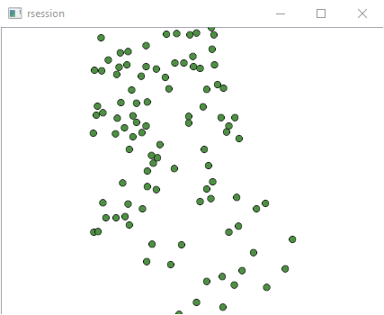

Figure 6: A very simple example how to access the QGIS map canvas from within R.

```r
# create the map canvas
py_run_string("canvas = QgsMapCanvas()")
# import point shapefile
py_run_string(sprintf("layer = QgsVectorLayer('%s', 'points', 'ogr')", file))
# add imported point layer to the map canvas
py_run_string("QgsMapLayerRegistry.instance().addMapLayer(layer)")
# set the extent of the map canvas to the extent of the imported shapefile
py_run_string("canvas.setExtent(layer.extent())")
# set the map canvas layer
py_run_string("canvas.setLayerSet([QgsMapCanvasLayer(layer)])")
# open a standalone window
py_run_string("canvas.show()")
# if a standalone window has not already opened, run the next line
# py_run_string("app.exec_()")
```

## 5 Discussion

### 5.1 R/GIS-integration: Combining the best of two worlds

In our use case (see section 3) we mainly used QGIS for raster preprocessing and the generation of terrain attributes. Naturally, there are many more geospatial analysis problems that can be solved using the thousands of geoalgorithms that are accessible through *RQGIS* and other R–GIS packages. For instance, SAGA provides more than 600 (Conrad et al. 2015) and GRASS more than 500 functions (http://grass.osgeo.org/grass72/manuals/).

Frequently, the residuals of spatial models show some form of spatial autocorrelation. This violates the assumption of independent model residuals made by most statistical models (Dormann et al. 2007; Zuur et al. 2009). Violating this assumption can lead to untrustworthy $p$ values, biased coefficients and subsequently poor predictions (Zuur et al. 2009). Fortunately, packages such as [*nlme*](https://CRAN.R-project.org/package=nlme) (Pinheiro et al. 2017) and [*mgcv*](https://CRAN.R-project.org/package=mgcv) (Wood 2017) let the user incorporate various correlation structures into a model. This is most helpful in the presence of temporal and spatial autocorrelation (e.g, Iturritxa et al. 2015). Sometimes mixed-effect models may also account for autocorrelation since random intercepts allow for correlation within a group (e.g., Peters et al. 2014). Another way of dealing with spatial autocorrelation is e.g., to include auto-regressive correlation structures in a GLM or GAM within a Bayesian modeling approach (Zuur and Ieno 2017).

To summarize, R offers an incredibly vast suite of advanced statistical and data science methods. On the other hand, QGIS and other GIS software offer a rich suite of geoalgorithms and geocomputational power. Interfacing R with GIS simply combines the best of two worlds for automated statistical geocomputing.

### 5.2 *RSAGA* and R/GRASS-integration

Compared to the two separate packages *rgrass7* and *RSAGA*, *RQGIS* has the advantage of providing a unified interface to both GRASS and SAGA GIS toolboxes. Moreover, QGIS facilitates the usage of third-party geoalgorithms by automatically converting vector (e.g., shapefiles) and raster formats (e.g., ASCII grid files) into the particular format supported by the third-party module. For instance, SAGA has its own grid format (sgrd-files) and GRASS uses its own database format. Running SAGA or GRASS functions, (R)QGIS automatically converts the input data using `io_gdal()` in the case of SAGA and `v.in.ogr()` or `r.in.gdal()` in the case of GRASS. Though this is extremely user-friendly especially when providing interfaces to various third-party providers, it comes at the prize of increased computing time due to the necessity of multiple format conversions during one geoalgorithm call. Equally user-friendly it the automatic setup of the GRASS environment (projection, region and mapset) through (R)QGIS, if necessary. This certainly facilitates access to GRASS, especially for less experienced GIS users. Finally, *RQGIS* is overall quite user-friendly due to its convenience functions `open_help()` and `get_args_man()` and through its support of R named arguments for geoalgorithm parameters (see sections 2.1 and 2.2).

However, (R)QGIS only integrates a subset of the modules available in SAGA and GRASS GIS. While this fraction is likely to grow in the near future, a full integration of all modules is improbable as it would duplicate functionality (though this of course already has happened) and interface functions that are unnecessary within the QGIS environment, such as the GRASS database functions. If the user’s intention is to use GRASS’s database management system (DBMS), the direct R–GRASS integration via the [*spgrass6*](https://CRAN.R-project.org/package=spgrass6) (Bivand et al. 2013) and *rgrass7* packages (Bivand and Neteler 2000) would be the appropriate path. *RQGIS* does not provide access to this DBMS since the GRASS plugin of the QGIS processing toolbox only allows restricted access to GRASS’s DBMS functionality. The use of *rgrass7* also allows the user to operate within a single GRASS session instead of calling a new one for each GRASS command as implicitly done by QGIS.

In the case of SAGA GIS, *RSAGA* has additional benefits. First of all, *RSAGA* provides numerous user-friendly wrapper functions with arguments (and meaningful default values) documented in the R help pages. *RSAGA* also strives to provide unified access to a range of SAGA versions while using, if possible, persistent function and argument names as well as default values. This allows for an easier migration between SAGA versions. At the moment *RSAGA* supports versions 2.0.4–2.2.3, but support for SAGA versions until the current version 6.1 has already been developed, and is currently being tested. By contrast, QGIS 2.14 supports SAGA 2.1.2–2.3.1. With the release of QGIS 2.18.10, this support was limited to the long term SAGA release 2.3.x. Extremely useful are furthermore *RSAGA*’s special geocomputing functions that allow, for example, the application of any user-defined R function to a stack of grids, either locally or within moving windows (functions `multi.focal.function()` and `multi.local.function()`). In conjunction with `grid.predict()`, predict methods of models fitted in R can therefore also be applied to stacks of raster files, as shown in Brenning (2008).

In the end, it will be up to the user to decide whether to use *RQGIS*, *RSAGA*, *rgrass7* or some combination of these, depending on the user’s preferences, expertise and tasks at hand. In any case, we would recommend *RQGIS* if a user

- requires mainly the more commonly used SAGA and GRASS functions,
- does not want to be bothered with setting up the GRASS environment,
- does not plan to use GRASS geodatabase capabilities,
- does not want to worry about spatial data format conversions,
- would like to use spatial objects residing in R as input-arguments, and load GIS output automatically into R,
- cherishes the flexibility of seamlessly integrating QGIS, GRASS, SAGA and other third-party software (GDAL/OGR, Orfeo Toolbox, LAStools, TauDEM) within a single geoprocessing workflow in R.

### 5.3 Accessing ArcGIS through *RPyGeo*

The integration of GIS functionality into R is not limited to the mentioned open-source GIS software, but also includes the global leader in commercial GIS software (Longley et al. 2011), ArcGIS, through the *RPyGeo* package (Brenning 2012a). This package piggybacks on ArcGIS’s own Python interface to ArcGIS functions, or ‘tools’. *RPyGeo* generates Python code that calls ArcGIS. Some of the challenges currently include

- latency times related to launching Python and ArcGIS before each GIS call,
- passing data and files between R and ArcGIS,
- error tracking based on Python and/or ArcGIS error messages,
- interpretation of ArcGIS help pages from the perspective of a geoprocessing interface function in R.

While some of these limitations may be overcome in future releases of *RPyGeo* and ArcGIS, the growing interest in integrating R and ArcGIS is also evident from recent efforts to provide access to R from within ArcGIS (https://r-arcgis.github.io/). This so-called R–Bridge allows users to

- retrieve data from ArcGIS geodatabases into R as `"sp"` objects, and export R data back into ArcGIS geodatabases,
- run R code within ArcGIS as a user-defined ‘tool’. This is similar to QGIS’s ability to integrate R scripts as user-defined GIS modules in the Processing toolbox.

While this connectivity, in principle, goes both ways, the integration of ArcGIS into R through the R–Bridge is currently limited to data import/export, which is complementary to *RPyGeo*’s capability of executing ArcGIS modules from within R.

### 5.4 Current and future developments

There are several interesting developing directions in the R-spatial world and for *RQGIS*. For example, we have been asked multiple times to include the QGIS mapping widget within R for fast interactive visualization and styling of multiple layers. In section 4 we have shown that this is theoretically possible. However, mixing R and Qt events seems to cause frequently trouble (also pers. comm. Barry Rowlingson). For instance, when running `QgsMapCanvas()` twice or enlarging the standalone window manually (Figure 6), one runs a high risk of crashing the current R session. Therefore, Kevin Stadler, Barry Rowlingson and Julia Wagemann have opted for a different approach realized within a [Google Summer of Code Project](https://summerofcode.withgoogle.com/archive/2017/projects/4854198344613888/). In this project they wrote the QGIS Plugin [Network API](https://gitlab.com/qgisapi/networkapi/tree/master) which enables the user to access the QGIS API via a HTTP interface from another language capable of making HTTP calls (such as R). Along with the sibling R package *qgisremote* (https://qgisapi.gitlab.io/qgisremote/index.html) this allows R users to seamlessly exchange spatial data between R and QGIS. For example, one can add vector and raster layers from within R to the QGIS map canvas, interactively edit them (such as adding new points or changing polygon vertices), and load the results back into R. Similarly, the packages *mapview* (build on top of [*leaflet*](https://CRAN.R-project.org/package=leaflet), Cheng et al. 2017) and *mapedit* lets the user interactively visualize and edit spatial objects on leaflet maps. The advantage of *qgisremote* over these two packages is that the QGIS map canvas probably is better able to handle larger quantities of spatial data compared to leaflet, and that it provides the user with the full power of a Desktop GIS for manually editing spatial data (trace, snap, etc.). Nevertheless, *mapview* is a great tool for interactive visualization, and *mapedit* is a good alternative for small and quick modifications of spatial vector data within R. Coming back to the user request to include the QGIS mapping widget into *RQGIS*, we can state that *qgisremote* already filled this gap perfectly. In summary, *RQGIS* and *qgisremote* complement one another. The first gives an R user direct access to the QGIS processing engine, and the latter hands an R user the power of a Desktop GIS graphical user interface.

Adding new functionalities to *RQGIS* will generally include Python programming. Since QGIS migrates from Python 2 to Python 3 by the end of 2017, it is probably best to postpone major *RQGIS* extensions until after the migration. To guarantee a smooth transition, and to offer the possibility to work either with QGIS 2 or QGIS 3, we have designed *RQGIS* in such a way that we ideally would merely have to add a Python 3 script to ‘inst/python’ to make *RQGIS* also work with QGIS 3. In the case of a bumpier transition than anticipated, *RQGIS* users may rest assured that *RQGIS* will work in any case with the QGIS long term release 2.18 which will be further developed and regularly updated (see https://www.qgis.org/en/site/getinvolved/development/roadmap.html#release-schedule).

Another envisaged *RQGIS* update includes the support for `"stars"` classes (see https://github.com/r-spatial/stars). *stars* aims to mainly extend the *raster* package.

## 6 Conclusions

Combining R and GIS software creates a powerful environment for advanced statistical geocomputing. *RQGIS* makes this also possible with QGIS—one of the most-widely used open-source GIS, which is therefore probably also very appealing to R users. Conveniently, *RQGIS* offers a unified interface to various desktop GIS (SAGA, GRASS, etc.) that are integrated into QGIS. The use of GIS tools is facilitated through auxiliary functions for the automatic retrieval of function arguments and their default values, the support of R named arguments in `run_qgis()`, the seamless exchange of spatial data types, and the quick access of the online help for any QGIS geoalgorithm.

## 7 Acknowledgments

We greatly appreciate the work of the QGIS development and the R core team. We are also greatly indebted to Dr. Rainer Krug (University of Zurich) who not only reviewed our manuscript two times but also improved it with his valuable suggestions. Of course, we thank Dr. Roger Bivand, our editor, for handling our manuscript. We are also grateful to Dr. Tomislav Hengl (SRIC – World Soil Information, Wageningen), and an anonymous reviewer for valuable feedback on a previous manuscript version. Finally, we would like to thank Barry Rowlingson (Lancaster University) for fruitful discussions on Python, QGIS and R.

### 7.1 Supplementary materials

Supplementary materials are available in addition to this article. It can be downloaded at RJ-2017-067.zip

### 7.2 CRAN packages used

maptools, raster, sp, sf, mapview, mapmisc, osmar, dodgr, RArcInfo, rgrass7, mapedit, rgdal, rgeos, RSAGA, RPyGeo, RQGIS, reticulate, rPython, sperrorest, nlme, mgcv, spgrass6, leaflet

### 7.3 CRAN Task Views implied by cited packages

Bayesian, ChemPhys, ClinicalTrials, Cluster, DynamicVisualizations, Econometrics, Environmetrics, Finance, HighPerformanceComputing, MixedModels, ModelDeployment, NumericalMathematics, OfficialStatistics, Psychometrics, Spatial, SpatioTemporal

J. Allaire, Y. Tang and M. Geelnard. *Reticulate: R interface to python.* 2017. URL https://CRAN.R-project.org/package=reticulate. R package version 1.3.1.

T. Appelhans, F. Detsch, C. Reudenbach and S. Woellauer. *Mapview: Interactive viewing of spatial data in r.* 2017. URL https://CRAN.R-project.org/package=mapview. R package version 2.2.0.

T. Appelhans and K. Russell. *Mapedit: Interactive editing of spatial data in r.* 2017. URL https://CRAN.R-project.org/package=mapedit. R package version 0.3.2.

C. J. G. Bellosta. *rPython: Package allowing r to call python.* 2015. URL https://CRAN.R-project.org/package=rPython. R package version 0.0-6.

R. Bivand. *rgrass7: Interface between GRASS 7 geographical information system and r.* 2017. URL https://CRAN.R-project.org/package=rgrass7. R package version 0.1-10.

R. Bivand. Using the R–GRASS interface. *OSGeo Journal*, 1: 36–38, 2007. URL http://fdo.osgeo.org/files/journal/final_pdfs/OSGeo_vol1_GRASS-R.pdf.

R. Bivand, T. Keitt and B. Rowlingson. *Rgdal: Bindings for the ’geospatial’ data abstraction library.* 2017. URL https://CRAN.R-project.org/package=rgdal. R package version 1.2-16.

R. Bivand and N. Lewin-Koh. *Maptools: Tools for reading and handling spatial objects.* 2017. URL https://CRAN.R-project.org/package=maptools. R package version 0.9-2.

R. Bivand and M. Neteler. Open source geocomputation: Using the R data analysis language integrated with GRASS GIS and PostgreSQL data base systems. In *GeoComputation*, 2000. URL http://www.geocomputation.org/2000/GC009/Gc009.htm.

R. Bivand, E. Pebesma and V. Gómez-Rubio. *Applied spatial data analysis with r.* 2nd ed New York: Springer, 2013. URL https://doi.org/10.1007/978-1-4614-7618-4.

R. Bivand and C. Rundel. *Rgeos: Interface to geometry engine - open source (’GEOS’).* 2017. URL https://CRAN.R-project.org/package=rgeos. R package version 0.3-26.

A. Brenning. *RPyGeo: ArcGIS geoprocessing in r via python.* 2012a. URL https://CRAN.R-project.org/package=RPyGeo. R package version 0.9-3.

A. Brenning. Spatial cross-validation and bootstrap for the assessment of prediction rules in remote sensing: The R package sperrorest. In *IEEE international symposium on geoscience and remote sensing IGARSS*, 2012b. URL https://doi.org/10.1109/IGARSS.2012.6352393.

A. Brenning. Spatial prediction models for landslide hazards: Review, comparison and evaluation. *Natural Hazards and Earth System Sciences*, 5(6): 853–862, 2005. URL https://doi.org/10.5194/nhess-5-853-2005.

A. Brenning. Statistical geocomputing combining R and SAGA: The example of landslide susceptibility analysis with generalized additive models. *Hamburger Beiträge zur Physischen Geographie und Landschaftsökologie*, 19: 23–32, 2008.

A. Brenning, S. Koszinski and M. Sommer. Geostatistical homogenization of soil conductivity across field boundaries. *Geoderma*, 143(3-4): 254–260, 2008. URL https://doi.org/10.1016/j.geoderma.2007.11.007.

A. Brenning, S. Long and P. Fieguth. Detecting rock glacier flow structures using gabor filters and IKONOS imagery. *Remote Sensing of Environment*, 125: 227–237, 2012. URL https://doi.org/10.1016/j.rse.2012.07.005.

A. Brenning, M. Schwinn, A. P. Ruiz-Páez and J. Muenchow. Landslide susceptibility near highways is increased by 1 order of magnitude in the Andes of Southern Ecuador, Loja Province. *Natural Hazards and Earth System Sciences*, 15(1): 45–57, 2015. URL https://doi.org/10.5194/nhess-15-45-2015.

P. E. Brown. Maps, coordinate reference systems and visualising geographic data with mapmisc. *The R Journal*, 8(1): 64–91, 2016. URL https://journal.r-project.org/archive/2016/RJ-2016-005/RJ-2016-005.pdf.

J. M. Chambers. *Extending R.* Boca Raton, Florida: Chapman & Hall CRC, 2016.

J. Cheng, B. Karambelkar and Y. Xie. *Leaflet: Create interactive web maps with the JavaScript ’leaflet’ library.* 2017. URL https://CRAN.R-project.org/package=leaflet. R package version 1.1.0.

L.-C. Chien, Y. Guo and K. Zhang. Spatiotemporal analysis of heat and heat wave effects on elderly mortality in Texas, 2006-2011. *Science of the Total Environment*, 562: 845–851, 2016. URL https://doi.org/10.1016/j.scitotenv.2016.04.042.

A. Comber, H. Balzter, B. Cole, P. Fisher, S. C. M. Johnson and B. Ogutu. Methods to quantify regional differences in land cover change. *Remote Sensing*, 8(3): 2016. URL https://doi.org/10.3390/rs8030176.

O. Conrad, B. Bechtel, M. Bock, H. Dietrich, E. Fischer, L. Gerlitz, J. Wehberg, V. Wichmann and J. Böhner. System for Automated Geoscientific Analyses (SAGA) v. 2.1.4. *Geoscientific Model Development*, 8(7): 1991–2007, 2015. URL https://doi.org/10.5194/gmd-8-1991-2015.

M. O. Dillon, M. Nakazawa and S. G. Leiva. The lomas formations of coastal Peru: Composition and biogeographic history. In *El niño in peru: Biology and culture over 10,000 years*, Eds J. Haas and M. O. Dillon pages. 1–9 2003. Chigaco: Field Museum of Natural History.

C. F. Dormann, J. M. McPherson, M. B. Araújo, R. Bivand, J. Bolliger, G. Carl, R. G. Davies, A. Hirzel, W. Jetz, W. D. Kissling, et al. Methods to account for spatial autocorrelation in the analysis of species distributional data: A review. *Ecography*, 30(5): 609–628, 2007. URL https://doi.org/10.1111/j.2007.0906-7590.05171.x.

ESRI. *ArcGIS, version 10.5.* 2017. URL http://www.arcgis.com.

M. J. A. Eugster and T. Schlesinger. Osmar: OpenStreetMap and R. *R Journal*, 5(1): 53–63, 2013. URL https://journal.r-project.org/archive/2013-1/eugster-schlesinger.pdf.

M. A. L. Fernandez, M. Schomaker, P. R. Mason, J. F. Fesselet, Y. Baudot, A. Boulle and P. Maes. Elevation and cholera: An epidemiological spatial analysis of the cholera epidemic in Harare, Zimbabwe, 2008-2009. *BMC Public Health*, 12: 2012. URL https://doi.org/10.1186/1471-2458-12-442.

J. Franklin, P. McCullough and C. Gray. Terrain variables used for predictive mapping of vegetation communities in Southern California. In *Terrain analysis*, Eds J. P. Wilson and J. C. Gallant pages. 331–353 2000. New York; Chichester: John Wiley & Sons. ISBN 978-0-471-32188-0.

GDAL Development Team. *GDAL - geospatial data abstraction library, version 2.2.2.* Open Source Geospatial Foundation, 2017. URL http://www.gdal.org.

GEOS Development Team. *GEOS - geometry engine open source, version 3.6.2.* Open Source Geospatial Foundation, 2017. URL https://trac.osgeo.org/geos.

J. N. Goetz, R. H. Guthrie and A. Brenning. Integrating physical and empirical landslide susceptibility models using generalized additive models. *Geomorphology*, 129(3-4): 376–386, 2011. URL https://doi.org/10.1016/j.geomorph.2011.03.001.

V. Gómez-Rubio and A. López-Quílez. RArcInfo: Using GIS data with R. *Computers & Geosciences*, 31(8): 1000–1006, 2005. URL https://doi.org/10.1016/j.cageo.2005.02.009.

A. Graser and V. Olaya. Processing: A Python framework for the seamless integration of geoprocessing tools in QGIS. *ISPRS International Journal of Geo-Information*, 4(4): 2219–2245, 2015. URL https://doi.org/10.3390/ijgi4042219.

C. H. Grohmann. Morphometric analysis in Geographic Information Systems: Applications of free software GRASS and R. *Computers & Geosciences*, 30(9-10): 1055–1067, 2004. URL https://doi.org/10.1016/j.cageo.2004.08.002.

T. Hastie. *Gam: Generalized additive models.* 2017. URL https://CRAN.R-project.org/package=gam. R package version 1.14-4.

T. Hengl, G. B. M. Heuvelink and E. E. van Loon. On the uncertainty of stream networks derived from elevation data: The error propagation approach. *Hydrology and Earth System Sciences*, 14(7): 1153–1165, 2010. URL https://doi.org/10.5194/hess-14-1153-2010.

T. Hengl, P. Roudier, D. Beaudette and E. Pebesma. plotKML: Scientific visualization of spatio-temporal data. *Journal of Statistical Software*, 63(5): 2015. URL https://doi.org/10.18637/jss.v063.i05.

R. J. Hijmans. *Raster: Geographic data analysis and modeling.* 2017. URL https://CRAN.R-project.org/package=raster. R package version 2.6-7.

J. Inglada and E. Christophe. The Orfeo Toolbox remote sensing image processing software. In *Geoscience and remote sensing symposium, 2009 IEEE international, IGARSS 2009*, pages. IV–733 2009.

E. Iturritxa, N. Mesanza and A. Brenning. Spatial analysis of the risk of major forest diseases in Monterey pine plantations. *Plant Pathology*, 64(4): 880–889, 2015. URL https://doi.org/10.1111/ppa.12328.

R. Jones-Webb and M. Wall. Neighborhood racial/ethnic concentration, social disadvantage, and homicide risk: An ecological analysis of 10 US cities. *Journal of Urban Health*, 85(5): 662–676, 2008. URL https://doi.org/10.1007/s11524-008-9302-y.

J. Kühn, A. Brenning, M. Wehrhan, S. Koszinski and M. Sommer. Interpretation of electrical conductivity patterns by soil properties and geological maps for precision agriculture. *Precision Agriculture*, 10(6): 490–507, 2009. URL https://doi.org/10.1007/s11119-008-9103-z.

P. Longley, M. Goodchild, D. J. Maguire and D. W. Rhind. *Geographic information systems and science.* 3rd ed. Hoboken, N.J: John Wiley & Sons, 2011.

A. B. McBratney, I. O. A. Odeh, T. F. A. Bishop, M. S. Dunbar and T. M. Shatar. An overview of pedometric techniques for use in soil survey. *Geoderma*, 97(3-4): 293–327, 2000. URL https://doi.org/10.1016/S0016-7061(00)00043-4.

M. Mergili and H. Kerschner. Gridded precipitation mapping in mountainous terrain combining GRASS and R. *Norsk Geografisk Tidsskrift-Norwegian Journal of Geography*, 69(1): 2–17, 2015. URL https://doi.org/10.1080/00291951.2014.992807.

M. Mergili, J. Krenn and H.-J. Chu. R.randomwalk v1, a multi-functional conceptual tool for mass movement routing. *Geoscientific Model Development*, 8(12): 4027–4043, 2015. URL https://doi.org/10.5194/gmd-8-4027-2015.

D. R. Montgomery and W. E. Dietrich. A physically based model for the topographic control on shallow landsliding. *Water Resources Research*, 30(4): 1153–1171, 1994. URL https://doi.org/10.1029/93WR02979.

D. Moreno-Fernández, I. Cañellas, I. Barbeito, M. Sánchez-González and A. Ledo. Alternative approaches to assessing the natural regeneration of Scots pine in a mediterranean forest. *Annals of Forest Science*, 72(5): 569–583, 2015. URL https://doi.org/10.1007/s13595-015-0479-4.

J. Muenchow, A. Bräuning, E. Frank Rodríguez and H. von Wehrden. Predictive mapping of species richness and plant species’ distributions of a Peruvian fog oasis along an altitudinal gradient. *Biotropica*, 45(5): 557–566, 2013a. URL https://doi.org/10.1111/btp.12049.

J. Muenchow, A. Brenning and M. Richter. Geomorphic process rates of landslides along a humidity gradient in the tropical Andes. *Geomorphology*, 139: 271–284, 2012. URL https://doi.org/10.1016/j.geomorph.2011.10.029.

J. Muenchow, P. Dieker, J. Kluge, M. Kessler and H. von Wehrden. A review of ecological gradient research in the Tropics: Identifying research gaps, future directions, and conservation priorities. *Biodiversity and Conservation*, 2017. URL https://doi.org/10.1007/s10531-017-1465-y.

J. Muenchow, H. Feilhauer, A. Bräuning, E. F. Rodríguez, F. Bayer, R. A. Rodríguez and H. von Wehrden. Coupling ordination techniques and GAM to spatially predict vegetation assemblages along a climatic gradient in an ENSO-affected region of extremely high climate variability. *Journal of Vegetation Science*, 24(6): 1154–1166, 2013b. URL https://doi.org/10.1111/jvs.12038.

J. Muenchow, S. Hauenstein, A. Bräuning, R. Bäumler, E. F. Rodríguez and H. von Wehrden. Soil texture and altitude, respectively, largely determine the floristic gradient of the most diverse fog oasis in the Peruvian desert. *Journal of Tropical Ecology*, 29: 427–438, 2013c. URL https://doi.org/10.1017/S0266467413000436.

J. Muenchow and P. Schratz. *RQGIS: Integrating r with QGIS.* 2017. URL https://CRAN.R-project.org/package=RQGIS. R package version 1.0.3.

M. Neteler and H. Mitasova. *Open source GIS: A GRASS GIS approach.* New York: Springer-Verlag, 2008.

M. Padgham and A. Peutschnig. *Dodgr: Distances on directed graphs.* 2017. URL https://CRAN.R-project.org/package=dodgr. R package version 0.0.3.

E. Pebesma. *Sf: Simple features for r.* 2017. URL https://CRAN.R-project.org/package=sf. R package version 0.5-5.

T. Peters, A. Bräuning, J. Muenchow and M. Richter. An ecological paradox: High species diversity and low position of the upper forest line in the Andean depression. *Ecology and Evolution*, 4(11): 2134–2145, 2014. URL https://doi.org/10.1002/ece3.1078.

R. J. Pike, I. S. Evans and T. Hengl. Geomorphometry: A brief guide. In *Geomorphometry*, Eds T. Hengl and H. I. Reuter pages. 1–28 2008. Amsterdam; Oxford: Elsevier. ISBN 0123743451.

J. Pinheiro, D. Bates and R-core. *Nlme: Linear and nonlinear mixed effects models.* 2017. URL https://CRAN.R-project.org/package=nlme. R package version 3.1-131.

L. Poggio and A. Gimona. Downscaling and correction of regional climate models outputs with a hybrid geostatistical approach. *Spatial Statistics*, 14: 4–21, 2015. URL https://doi.org/10.1016/j.spasta.2015.04.006.

L. Y. Pomara, K. Ruokolainen, H. Tuomisto and K. R. Young. Avian composition co–varies with floristic composition and soil nutrient concentration in Amazonian upland forests. *Biotropica*, 44(4): 545–553, 2012. URL https://doi.org/10.1111/j.1744-7429.2011.00851.x.

QGIS Development Team. *QGIS geographic information system, version 2.18.14-las palmas.* Open Source Geospatial Foundation, 2017. URL http://www.qgis.org/.

Rapidlasso. *LAStools, version 171124.* 2017. URL https://rapidlasso.com/lastools/.

B. Ripley, D. Bates and S. DebRoy. R data import/export. 2016. URL https://cran.r-project.org/doc/manuals/r-release/R-data.html.

D. Rocchini, L. Delucchi, G. Bacaro, P. Cavallini, H. Feilhauer, G. M. Foody, K. S. He, H. Nagendra, C. Porta, C. Ricotta, et al. Calculating landscape diversity with information-theory based indices: A GRASS GIS solution. *Ecological Informatics*, 17: 82–93, 2013. URL https://doi.org/10.1016/j.ecoinf.2012.04.002.

G. Sherman. *The PyQGIS programmer’s guide: Extending QGIS 2.x with python.* Chugiak Alas.: Locate Press, 2014.

D. G. Tarboton and I. N. Mohammed. *Terrain analysis using digital elevation models. TauDEM, version 5.* 2017. URL http://hydrology. usu. edu/taudem/taudem5/index.html.

K. A. Vanselow and C. Samimi. Predictive mapping of dwarf shrub vegetation in an arid high mountain ecosystem using remote sensing and random forests. *Remote Sensing*, 6(7): 6709–6726, 2014. URL https://doi.org/10.3390/rs6076709.

S. Wood. *Mgcv: Mixed GAM computation vehicle with automatic smoothness estimation.* 2017. URL https://doi.org/10.1111/j.1467-9868.2010.00749.x. R package version 1.8-20.

H. Zandler, A. Brenning and C. Samimi. Quantifying dwarf shrub biomass in an arid environment: Comparing empirical methods in a high dimensional setting. *Remote Sensing of Environment*, 158: 140–155, 2015. URL https://doi.org/10.1016/j.rse.2014.11.007.

A. F. Zuur and E. N. Ieno. *A beginner’s guide to regression models with spatial and temporal correlation.* Newburgh, UK: Highland Statistics Ltd., 2017.

A. F. Zuur, E. N. Ieno, N. Walker, A. A. Saveliev and G. M. Smith. *Mixed effects models and extensions in ecology with r.* New York: Springer-Verlag, 2009.